# Severity of Car Traffic Accidents in Orange County in North Carolina

Alex Sorto

12/5/2021

### Research Questions

1. How severe are traffic accidents in Orange County?

Method: Create a table and histogram showing statistics of this variable.

### Data Preparation

#### Sources:

[CSV of traffic accidents in NC would focus on](https://www.kaggle.com/sobhanmoosavi/us-accidents) I would use this source to use longitude and latitude points to plot in my map. [North Carolina layer shapefile](https://www.nconemap.gov/datasets/NCDOT::ncdot-city-boundaries/explore?location=38.662466%2C-73.840143%2C6.76) I would use this source for the layer/shapefile for the map to make a choropleth potentially. [North Carolina layer shapefile](https://data-ncdenr.opendata.arcgis.com/datasets/nc-counties/explore?location=35.154172%2C-79.919249%2C7.94) This is another good layer for making a choropleth.

```r
# Read csv dataset of accidents
accidentsdataset <- read_excel("./Data/OrangeCountyAccidents.xlsx")
```

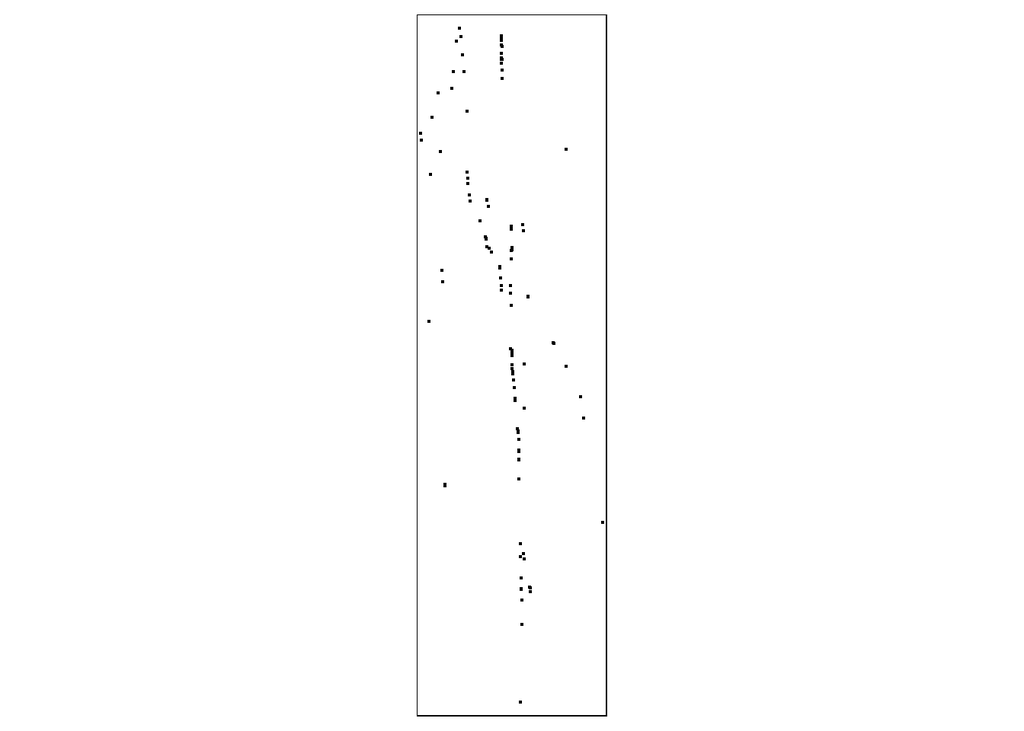

```r
# Convert csv to points layer
points <- st_as_sf(accidentsdataset, coords = c("Start_Lat", "Start_Lng"))
tm_shape(points) + tm_dots ()
```

#### Additional Information to note

Additionally, Excel was used to filter accidents in Orange County only, as opposed to the country it is in which the dataset included.

### Exploratory Spatial Data Analysis

#### Descriptive Statistics Table

```r
# Create summary information holder
summary.table <- tibble(Measure = c("Observations",
                                    "Minimum",
                                    "Maximum",
                                    "Mean",
                                    "Median",
                                    "Standard Deviation"),
                        Cases = c(sum(!is.na(accidentsdataset$`Severity`)),
                                       min(accidentsdataset$`Severity`, na.rm = TRUE),
                                       max(accidentsdataset$`Severity`, na.rm = TRUE),
                                       mean(accidentsdataset$`Severity`, na.rm = TRUE),
                                       median(accidentsdataset$`Severity`, na.rm = TRUE),
                                       sd(accidentsdataset$`Severity`, na.rm = TRUE)
                                       )


                        )

## Print nice version of the table
kable(summary.table,
      digits = 1,
      format.args = list(big.mark = ",",
                         scientific = FALSE,
                         drop0trailing = TRUE),
      caption = "Severity

Shows the severity of the accident, a number between 1 and 4, where 1 indicates the least impact on traffic (i.e., short delay ") %>%
  kable_styling(bootstrap_options = c("striped",
                                      "hover",
                                      "condensed",
                                      "responsive"),
                full_width = F)
```

| Measure | Cases |
| --- | --- |
| Observations | 205 |
| Minimum | 1 |
| Maximum | 4 |
| Mean | 2.3 |
| Median | 2 |
| Standard Deviation | 0.7 |

There are 205 observations in the dataset and the mean is 2.3 while the median is 2 in the scale of severity. There is some variation in the severity, shown with the standard deviation.

### Create a Histogram or Plot

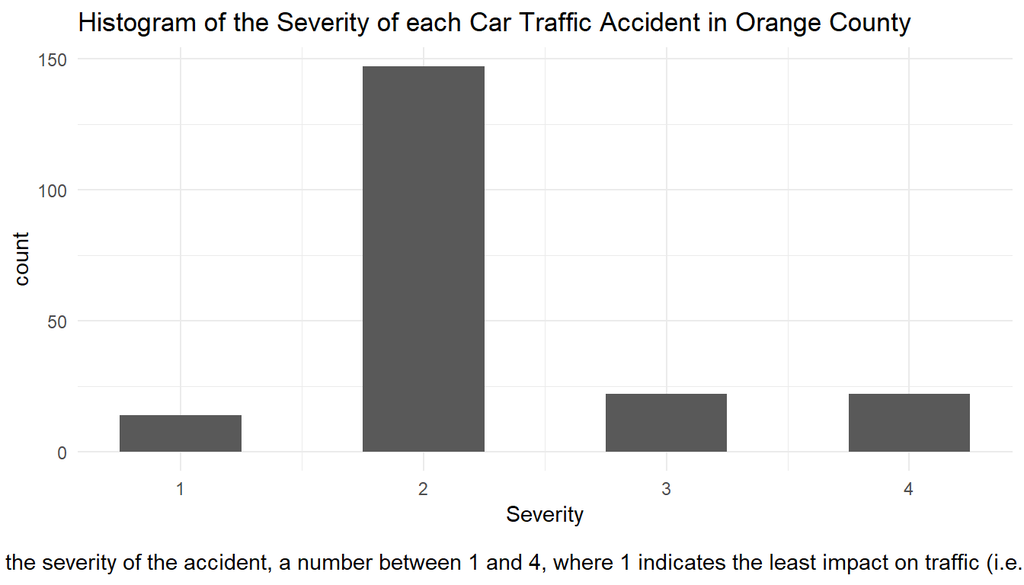

```r
## plot histogram
ggplot(accidentsdataset,
       aes(x = `Severity`)) +
  geom_histogram(binwidth = 0.5) +
  xlab("Severity

Shows the severity of the accident, a number between 1 and 4, where 1 indicates the least impact on traffic (i.e., short delay).") +
  ggtitle("Histogram of the Severity of each Car Traffic Accident in Orange County") +
  theme_minimal()
```

The histogram shows severity is mostly concentrated in the 2 values, and there are some accidents that had 3 and 4 severity values. This relates to this study since one can determine the safety of the roads in the county; overall, most accidents are not severe.

### Geographic Distribution and Spatial Clustering

[figure not shown]

```r
orangecounty <- st_read("./Data/dissolved_orangecounty.shp", quiet = TRUE)

orangecounty.projected <- st_transform(orangecounty,
                        crs = 32119)

points.projected <- st_set_crs(points,
                        32119)

points.ppp <- as(points.projected, "Spatial") %>% as("ppp")

## Note that these are UNMARKED points
marks(points.ppp) <- NULL



## Provide it with the Orange County STUDY AREA bounds as a window
Window(points.ppp) <- as(orangecounty.projected, "Spatial") %>% as("owin")

## Plot the layer to ensure that the boundary is properly defined
plot(points.ppp,
     main = NULL,
     cols = rgb(0, 0, 0, 0.5),
     pch = 20)

points.ppp.quadrat <- quadratcount(points.ppp, nx = 10, ny = 10)

## Plot the layer with quadrat counts
plot(points.ppp,
     main = NULL,
     cols = "grey70",
     pch = 20)
plot(points.ppp.quadrat,
     add = TRUE,
     cex = 0.75)
```

```r
points.ppp.quadrat.test <- quadrat.test(points.ppp,
                                         nx = 5,
                                         ny = 5)
## Calculate and print Variance to Mean Ratio
points.ppp.VMR <- var(points.ppp.quadrat.test$observed) / mean(points.ppp.quadrat.test$observed)
points.ppp.VMR
```

```
## [1] NA
```

```r
## Print test results to screen
points.ppp.quadrat.test
```

```
##
##  Chi-squared test of CSR using quadrat counts
##
## data:  points.ppp
## X2 = 4416.2, df = 24, p-value < 2.2e-16
## alternative hypothesis: two.sided
##
## Quadrats: 25 tiles (irregular windows)
```

[figure not shown]

```r
## Remember the warning about expected counts?
## Let's increase the size of that quadrats to increase
## the number of Fire Stations in each
## We will use twice as many rows as columns, given data shape
points.ppp.quadrat <- quadratcount(points.ppp,
                                    nx = 4,
                                    ny = 4)

## Plot the quadrat counts
plot(points.ppp.quadrat,
     cex = 0.75)
```

```r
points.ppp.quadrat.test <- quadrat.test(points.ppp,
                                         nx = 4,
                                         ny = 4)
## Calculate and print Variance to Mean Ratio
points.ppp.VMR <- var(points.ppp.quadrat.test$observed) / mean(points.ppp.quadrat.test$observed)
points.ppp.VMR
```

```
## [1] NA
```

```r
## Print test results to screen
points.ppp.quadrat.test
```

```
##
##  Chi-squared test of CSR using quadrat counts
##
## data:  points.ppp
## X2 = 1029.3, df = 15, p-value < 2.2e-16
## alternative hypothesis: two.sided
##
## Quadrats: 16 tiles (irregular windows)
```

#### Layers of Orange County and Car accidents used for Quadrat Analysis:

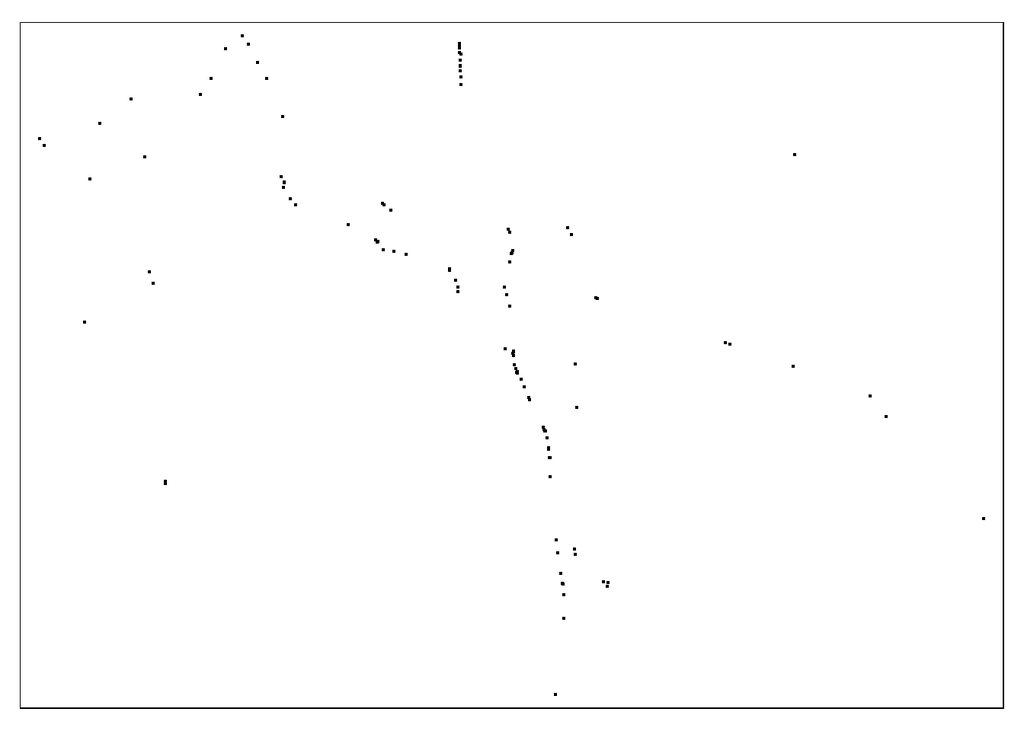

```r
tm_shape(points.projected) + tm_dots()
```

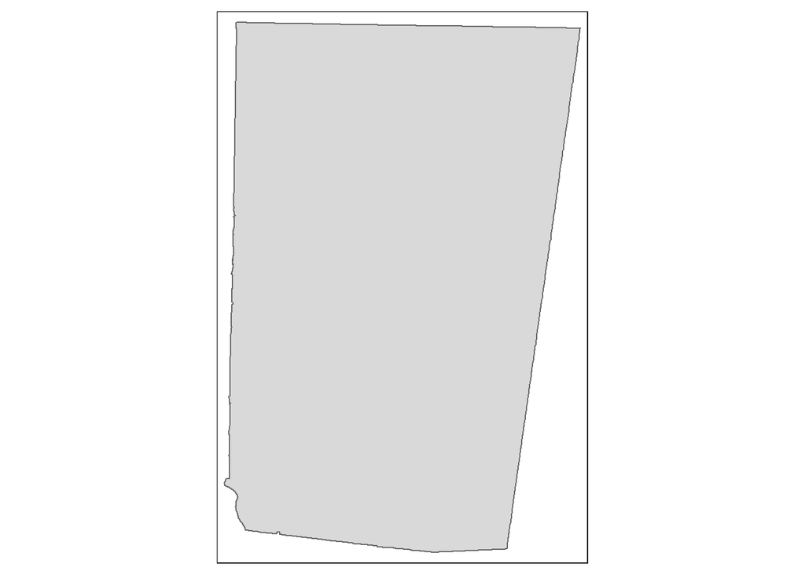

```r
tm_shape(orangecounty) +tm_polygons()
```

### Conclusion

This study shows that while there have been accidents in Orange County, most are not severe according to the 1-4 scale. Most traffic accidents are categorized as 2 on the severity scale. Aside from the statistics shown, a quadrat analysis was conducted to study the dispersion of traffic accidents.

#### Word Count

| Method | koRpus | stringi |
| --- | --- | --- |
| Word count | 369 | 359 |
| Character count | 2341 | 2341 |
| Sentence count | 25 | Not available |
| Reading time | 1.8 minutes | 1.8 minutes |